# Lesson 06: Continuous Distributions

21 July, 2018

## 1.) Shoppers

Assume the purchases of shoppers in a store have been studied for a period of time and it is determined the daily purchases by individual shoppers are normally distributed with a mean of $81.14 and a standard deviation of $20.71. Find the following probabilities using R.

### a.)

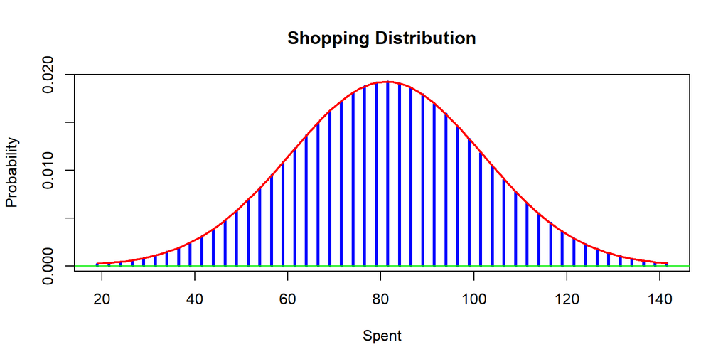

```r
u <- 81.14
sd <- 20.71

x <- seq(from = u - ( sd * 3 ), to = u + ( sd * 3), by = 2.5)

probs <- dnorm(x, u, sd)

plot(x, probs, type = "h", lwd = 3, col = "blue",
  main = "Shopping Distribution", xlab = "Spent", ylab = "Probability")
abline(h = 0, col = "green2")
curve(dnorm(x, u, sd), lwd = 2, col = "red", add = T)
```

> What is the probability that a randomly chosen shopper spends less than $75.00

```r
q1a <- pnorm(75, mean = u, sd = sd, lower.tail = T)
round(q1a, 4)
```

```
## [1] 0.3834
```

### b.)

> What proportion of shoppers spends more than $100.00?

```r
q1b <- pnorm(100, mean = u, sd = sd, lower.tail = F)
round(q1b, 4)
```

```
## [1] 0.1812
```

### c.)

> What proportion of shoppers spends between $50.00 and $100.00?

```r
q1c <- pnorm(50, mean = u, sd = sd, lower.tail = F) - pnorm(100, mean = u, sd = sd, lower.tail = F)
round(q1c, 4)
```

```
## [1] 0.7524
```

## 2.)

Assume that the shopper’s purchases are normally distributed with a mean of $97.11 and a standard deviation of $39.46. Find the following scores using R.

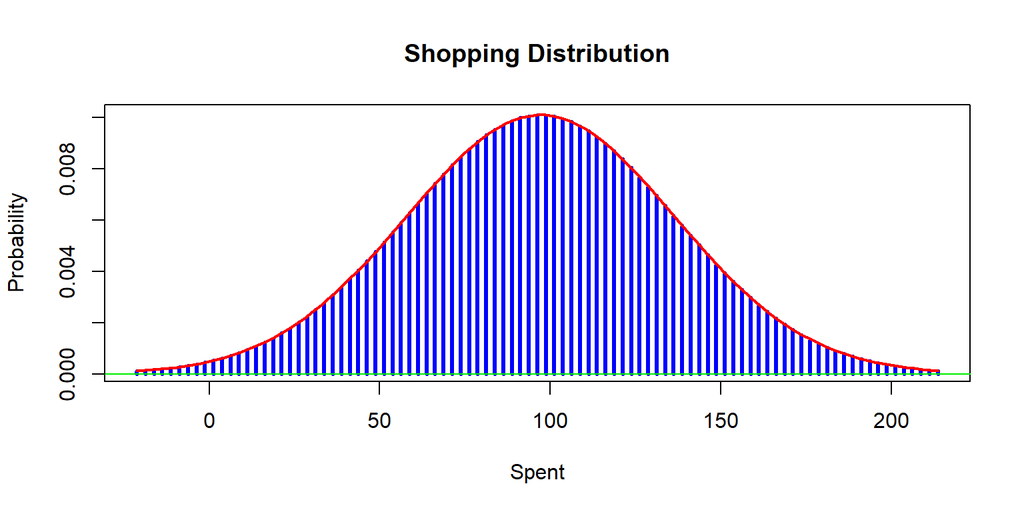

```r
u <- 97.11
sd <- 39.46

x <- seq(from = u - ( sd * 3 ), to = u + ( sd * 3), by = 2.5)

probs <- dnorm(x, u, sd)

plot(x, probs, type = "h", lwd = 3, col = "blue",
  main = "Shopping Distribution", xlab = "Spent", ylab = "Probability")
abline(h = 0, col = "green2")
curve(dnorm(x, u, sd), lwd = 2, col = "red", add = T)
```

### a.)

> What weight is the 90th Percentile of the shoppers’ purchases? That is, find the score P90 that separates the bottom 90% of shoppers’ purchases from the top 10%

```r
qnorm(.9, u, sd = sd)
```

```
## [1] 147.68
```

### b.)

> What is the median shoppers’ purchase? (Find the score P50 that separates the bottom 50% of shoppers’ purchases from the top 50%.) What is important about this number?

```r
qnorm(.5, u, sd)
```

```
## [1] 97.11
```

## 3.)

- Generate a sample of size 50 from a normal distribution with a mean of 100 and a standard deviation of 4.
- What is the sample mean and sample standard deviation? Calculate the standard error of the mean for this sample. Generate a second sample of size 50 from the same normal population.
- What is the sample mean and sample standard deviation? Calculate the standard error of the mean for this sample.
- Compare your results. Are the sample means and sample standard deviations of random samples of the same size taken from the same population identical? Why or why not?
- Now, repeat this process generating a sample of size 5000.
- Calculate the sample mean, sample standard deviation and standard error of the mean for this third sample and compare to the previous samples.

```r
set.seed(1234)

n <- 50
u <- 100
sd <- 4
d <- rnorm(n, u, sd)

std_err <- sd / sqrt(n)

sprintf("Sample Stats - Mean: %.4f, Std Dev: %.4f, Std Err: %.4f", mean(d), sd(d), std_err )
```

```
## [1] "Sample Stats - Mean: 98.1878, Std Dev: 3.5402, Std Err: 0.5657"
```

```r
d <- rnorm(n, u, sd)

std_err <- sd / sqrt(n)

sprintf("Sample Stats - Mean: %.4f, Std Dev: %.4f, Std Err: %.4f", mean(d), sd(d), std_err)
```

```
## [1] "Sample Stats - Mean: 100.5581, Std Dev: 4.1488, Std Err: 0.5657"
```

```r
n <- 5000
d <- rnorm(n, u, sd)

std_err <- sd / sqrt(n)

sprintf("Sample Stats - Mean: %.4f, Std Dev: %.4f, Std Err: %.4f", mean(d), sd(d), std_err)
```

```
## [1] "Sample Stats - Mean: 99.9920, Std Dev: 3.9669, Std Err: 0.0566"
```

## 4.)

Assume a biased coin when flipped will generate heads one third of the time. Estimate the probability of getting at least 250 heads out of 600 flips using the normal distribution approximation. Compare to the exact probability using the binomial distribution

```r
# Normal approximation to the binomial uses z = (x - n*p)/sqrt(n * p * (1-p))
n <- 600
p <- 1 / 3
x <- 250 # least 250 heads implies the upper tail of the standard normal distribution

sprintf("%.6f", pbinom(q = x, size = n, prob = p, lower.tail = FALSE))
```

```
## [1] "0.000009"
```

```r
# The normal approximation to the binomial is very close to the binomial.
xCorrect <- 250 - 0.5
z <- (xCorrect - n * p) / sqrt(n * p * (1 - p))
sprintf("%.6f", pnorm(z, mean = 0, sd = 1, lower.tail = FALSE))
```

```
## [1] "0.000009"
```

## 5.)

Use the uniform distribution over 0 to 1. Generate three separate simple random samples of size n = 25, n = 100, n = 400. Plot histograms for each and comment on what you observe.

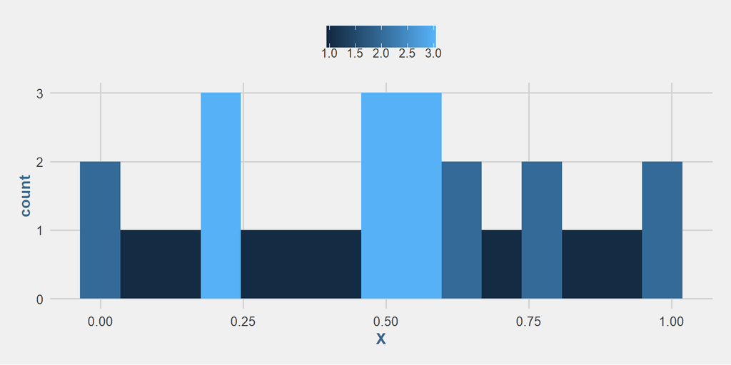

```r
unif_hist <- function(n, b) {
    d <- as.data.table(X <- runif(n, 0, 1))

    ggplot(d, aes(x = X, fill = ..count..)) +
        geom_histogram( breaks = pretty(d$X), bins = b)
}

unif_hist(25, 15)
```

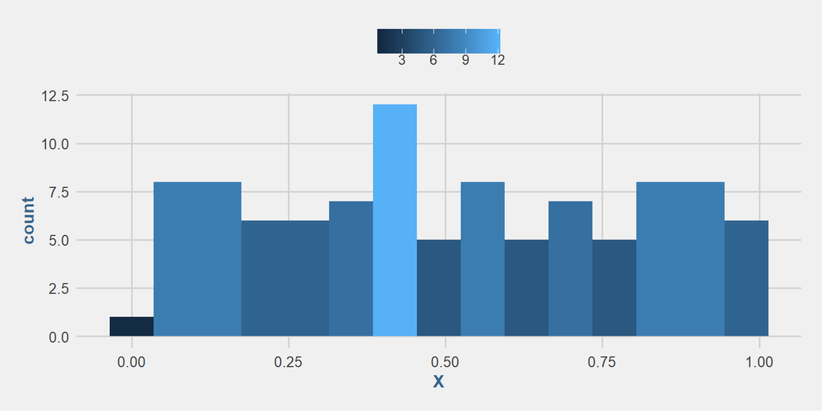

```r
unif_hist(100, 15)
```

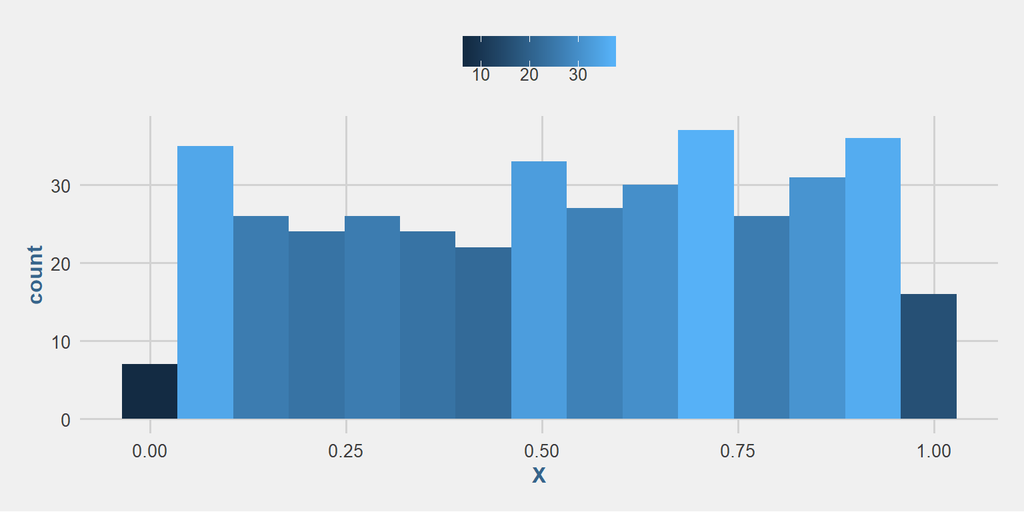

```r
unif_hist(400, 15)
```

## 6.)

salaries.csv gives the CEO age and salary for 60 small business firms. Construct QQ plots and histograms. Is the distribution of ages a normal distribution? Explain your answer.

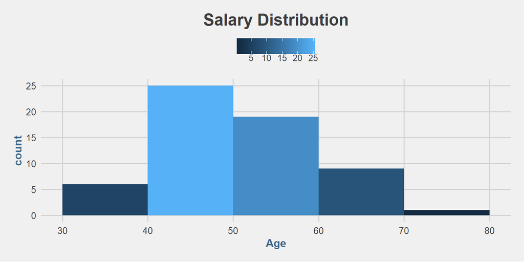

```r
salaries <- loadDataFile("salaries.csv")

ggplot(salaries, aes(x = Age, fill = ..count..)) +
    geom_histogram(breaks = pretty(salaries$Age)) +
    labs(title = "Salary Distribution")
```

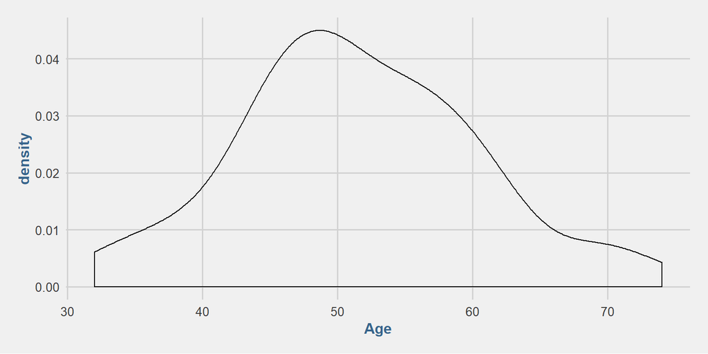

```r
ggplot(salaries, aes(x = Age)) +
    geom_density()
```

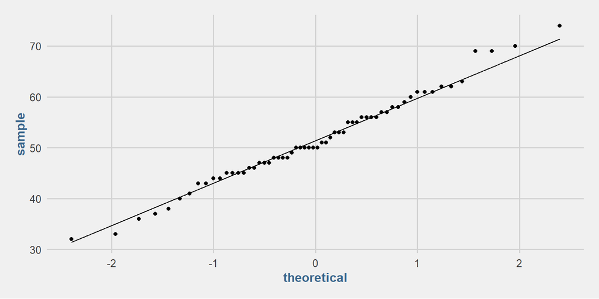

```r
ggplot(salaries, aes(sample = Age)) +
    stat_qq() +
    stat_qq_line()
```